# Categorização das respostas Pontos Frageis e Fortes

Henrique Pinto Gomide

20-08-2014

# Introdução

1. Pontos frageis
2. Pontos fortes

Dentro de cada grande estrutura, você deverá ver as análises separadas entre radicais e palavras completas. Lembre-se das vantagens e desvantagens de cada um que discutimos.

Ao final, a parte mais difícil. Você precisará ter calma e identificar quais as palavras estão mais correlacionadas. Eu deixei ao final do documento para não afastar as partes anteriores com muito texto.

Não se esqueça de ir criando possíveis categorias durante as análises e de conferir sua validade com o arquivo em planilha.

Boa sorte e bom trabalho,

:)

# Pontos Fracos

## Palavras

Estas são as palavras mais frequentes (com mais de 200 ocorrências):

```
##  [1] "alguns"       "alunos"       "aprendizagem" "atividades"
##  [5] "ausência"     "comunidade"   "cooperação"   "drogas"
##  [9] "escola"       "escolar"      "escolares"    "falta"
## [13] "família"      "familiar"     "familiares"   "famílias"
## [17] "pais"         "pontos"       "presença"     "professores"
## [21] "relação"      "relações"     "sobre"        "uso"
## [25] "usuários"     "vida"
```

### Gráfico de correlação entre as palavras

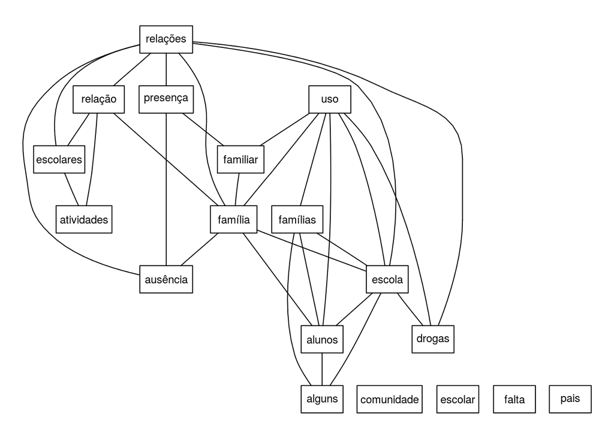

```r
plot(dtmWeak, terms = findFreqTerms(dtmWeak, lowfreq= 300), corThreshold=.3)
```

### Clusters

Este é o resultado da análise de Clusters

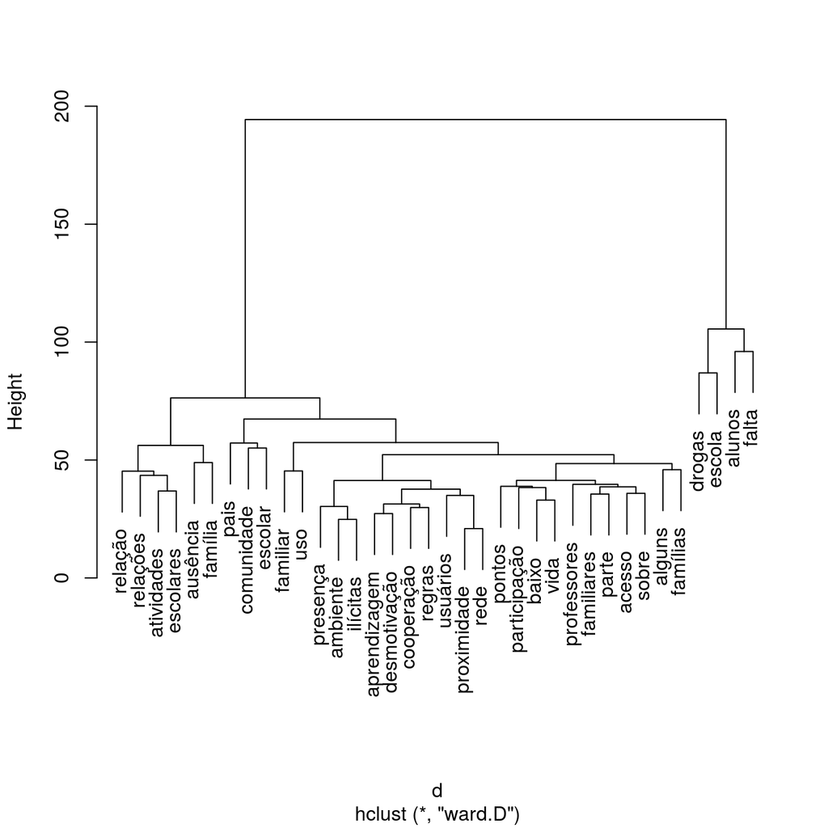

```r
# Scale
mydata.df.scale <- scale(mydataWeak)
d <- dist(mydata.df.scale, method = "euclidean") # distance matrix
fitA <- hclust(d, method="ward.D")
plot(fitA, main="") # display dendogram
```

## Radicais

Nesta sessão, são descritas as análises feitas com os radicais das palavras.

### Frequência

```
##  [1] "adolescent" "alguns"     "alun"       "ambient"    "aprendizag"
##  [6] "ativ"       "ausênc"     "baix"       "comun"      "cooper"
## [11] "drog"       "educ"       "envolv"     "escol"      "falt"
## [16] "famíl"      "famili"     "muit"       "outr"       "pais"
## [21] "particip"   "pont"       "pouc"       "presenc"    "professor"
## [26] "projet"     "red"        "relaçã"     "relaçõ"     "sobr"
## [31] "trabalh"    "uso"        "usuári"     "vid"
```

### Gráfico de correlação entre os radicais

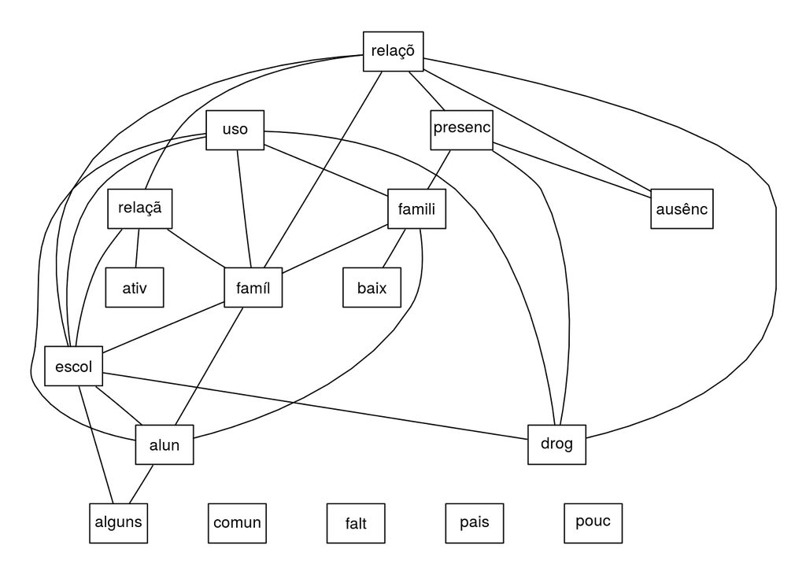

```r
plot(dtmWeakS, terms = findFreqTerms(dtmWeakS, lowfreq= 300), corThreshold=.3)
```

## Clusters

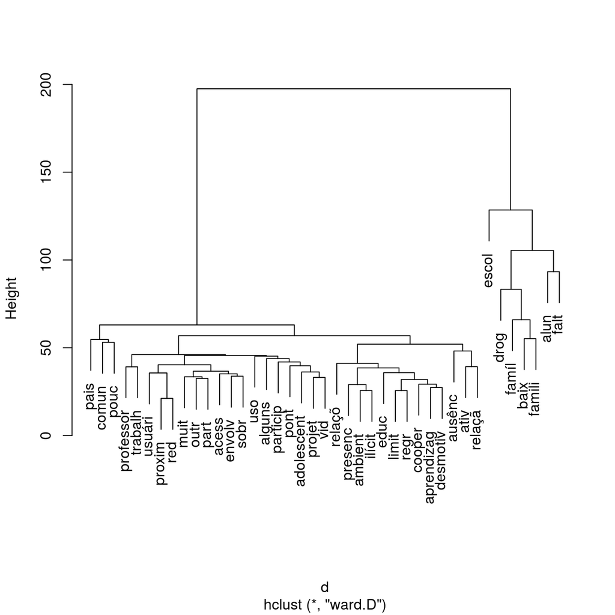

```r
plot(fitB, main="") # display dendogram
```

# Pontos Fortes

## Palavras

Estas são as palavras mais frequentes (com mais de 200 ocorrências):

```
##  [1] "aluno"         "alunos"        "ambiente"      "atividades"
##  [5] "bom"           "comunidade"    "cooperação"    "drogas"
##  [9] "equipe"        "escola"        "escolar"       "escolares"
## [13] "estímulo"      "família"       "fortes"        "presença"
## [17] "professores"   "profissionais" "projetos"      "regras"
## [21] "relação"       "relações"      "respeito"      "sobre"
## [25] "trabalho"      "valorização"
```

### Gráfico de correlação entre as palavras

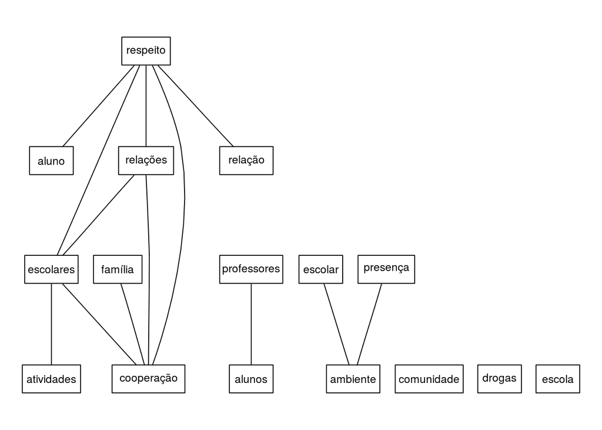

```r
plot(dtmStrong, terms = findFreqTerms(dtmStrong, lowfreq= 300), corThreshold=.3)
```

### Clusters

Este é o resultado da análise de Clusters

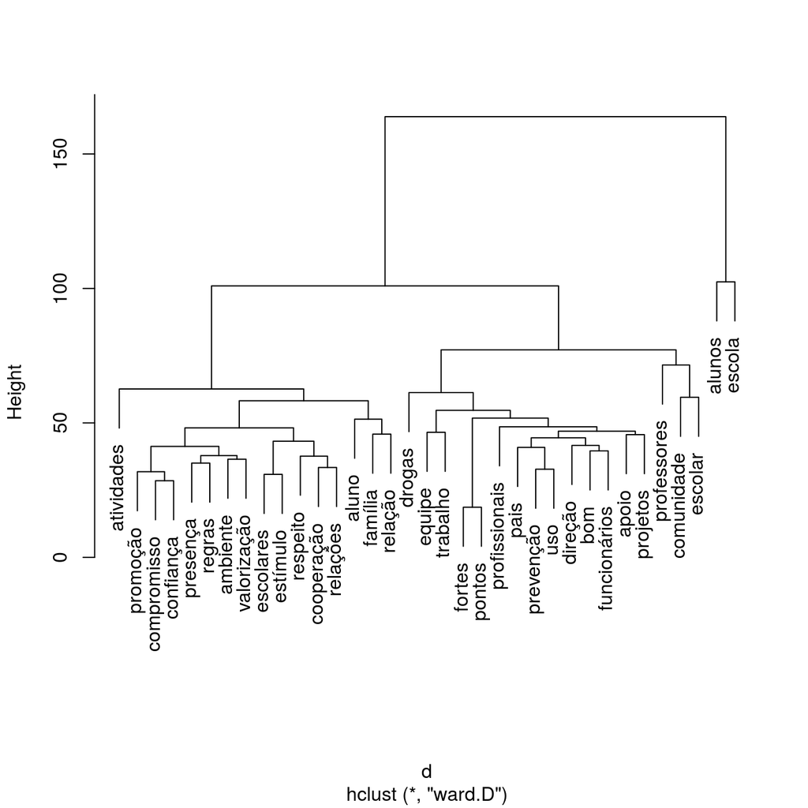

```r
plot(fit, main="") # display dendogram
```

## Radicais

Nesta sessão, são descritas as análises feitas com os radicais das palavras.

### Frequência

```
##  [1] "afet"       "alun"       "ambient"    "apoi"       "ativ"
##  [6] "bom"        "comun"      "cooper"     "desenvolv"  "drog"
## [11] "educ"       "envolv"     "equip"      "escol"      "estímul"
## [16] "famíl"      "fort"       "parc"       "particip"   "pedagóg"
## [21] "presenc"    "professor"  "profission" "projet"     "realiz"
## [26] "regr"       "relaçã"     "relaçõ"     "respeit"    "sobr"
## [31] "tod"        "trabalh"    "valoriz"
```

### Gráfico de correlação entre os radicais

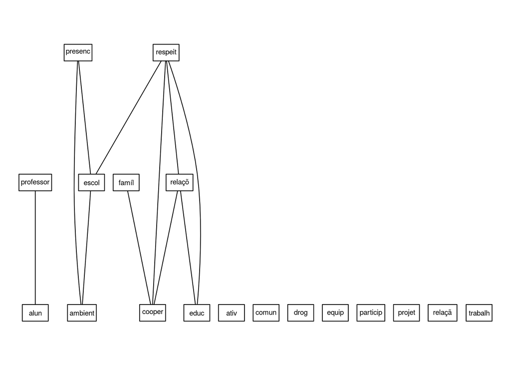

```r
plot(dtmStrongS, terms = findFreqTerms(dtmStrongS, lowfreq= 300), corThreshold=.3)
```

## Clusters

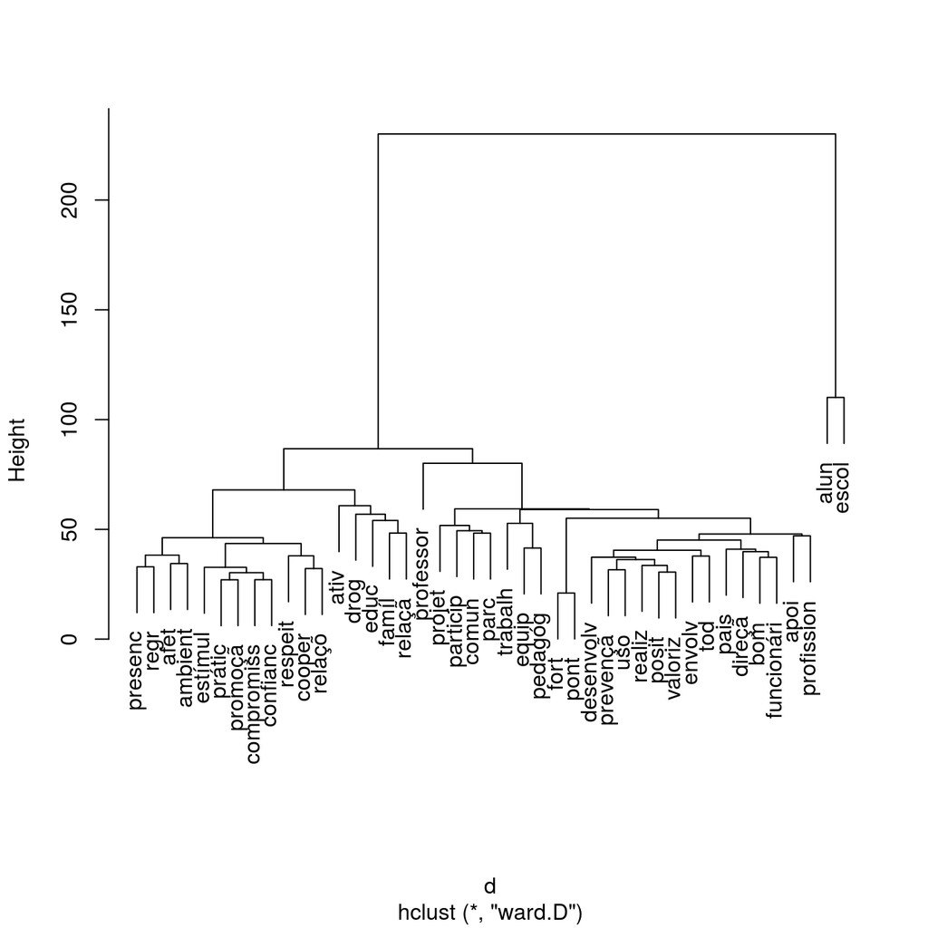

```r
plot(fit, main="") # display dendogram
```

# Correlações entre os termos e palavras

## Pontos Frageis

### Correlação entre os radicais mais frequentes

```r
for (i in 1:length(freqWordsWeakS)) {
  word  <- freqWordsWeakS[i]
  termo  <- findAssocs(dtmWeakS, word, corlimit=0.3)
  print(termo)
}
```

```
##              adolescent
## futur              0.38
## expect             0.37
## baix               0.33
## constitu           0.32
## marc               0.32
## agrid              0.31
## andar              0.31
## avôs               0.31
## concret            0.31
## consig             0.31
## daqu               0.31
## evasõ              0.31
## fissur             0.31
## inquiet            0.31
## notável            0.31
## núcl               0.31
## pes                0.31
## recaíd             0.31
## reinserçã          0.31
## repar              0.31
## satisfazerlh       0.31
## soub               0.31
## transgressã        0.31
## compr              0.30
## grup               0.30
##              alguns
## alun           0.40
## algum          0.37
## temp           0.37
## outr           0.36
## receb          0.36
## indisponibil   0.35
## oriund         0.34
## bairr          0.33
## determin       0.33
## nunc           0.33
## procur         0.33
## realment       0.33
## afirm          0.32
```

[output cut: 1685 more lines]

```
## principal    0.34
## déficit      0.33
## instituiçã   0.33
## sab          0.33
## tent         0.33
## estar        0.32
## event        0.32
## desconhec    0.31
## educ         0.31
## local        0.31
## particip     0.31
## relaçã       0.31
## respeit      0.31
## físic        0.30
## invest       0.30
```

### Correlação entre as palavras mais frequentes

```r
for (i in 1:length(freqWordsWeak)) {
  word  <- freqWordsWeak[i]
  termo  <- findAssocs(dtmWeak, word, corlimit=0.3)
  print(termo)
}
```

```
##                   alguns
## alunos              0.41
## participar          0.38
## recebe              0.37
## tempo               0.37
## bairros             0.36
## outros              0.36
## indisponibilidade   0.35
## algumas             0.34
## atendidas           0.34
## escolas             0.34
## oriundos            0.34
## procuram            0.34
## distantes           0.33
## estados             0.33
## estudar             0.33
## muitos              0.33
## nunca               0.33
## realmente           0.33
## recebidos           0.33
## relacionamentos     0.33
## sabemos             0.33
## abalado             0.32
## afirmar             0.32
## alteração           0.32
## amor                0.32
## apesar              0.32
## competências        0.32
## comunicacionais     0.32
## construídas         0.32
## decorrer            0.32
## deixam              0.32
## delimitado          0.32
## determinado         0.32
## diferem             0.32
## escola              0.32
## esforço             0.32
## frequentaram        0.32
## humano              0.32
## mesclam             0.32
```

[output cut: 1484 more lines]

```
## histórico         0.34
## muitos            0.34
## déficit           0.33
## estar             0.33
## instituição       0.33
## principalmente    0.33
## respeito          0.33
## desconhecimento   0.32
## espaço            0.32
## eventos           0.32
## local             0.32
## recebe            0.32
## todos             0.32
## relação           0.31
## familiar          0.30
```

## Pontos Fortes

### Correlação entre os radicais mais frequentes

```r
for (i in 1:length(freqWordsStrongS)) {
  word  <- freqWordsStrongS[i]
  termo  <- findAssocs(dtmStrongS, word, corlimit=0.3)
  print(termo)
}
```

```
##            afet
## víncul     0.62
## confianc   0.49
## ambient    0.40
## norm       0.36
## fort       0.35
## agent      0.33
## amist      0.33
## cooper     0.32
## definiçã   0.32
## mútu       0.32
## compromiss 0.31
## alun.professor
##            0.3
##          ambient
## protetor    0.50
## segur       0.50
## confianc    0.42
## afet        0.40
## presenc     0.40
## escol       0.39
## regr        0.35
## $apoi
## numeric(0)
##
##          ativ
## estímul  0.41
## cultur   0.40
## esport   0.40
## promoçã  0.34
## prátic   0.33
## signific 0.31
## soc      0.30
## bom.relacion
##         0.58
##            comun
## intercâmbi  0.43
## situ        0.36
## rural       0.35
## livr        0.33
```

[output cut: 280 more lines]

```
## pontu     0.30
## renov     0.30
## soment    0.30
## trás      0.30
##            trabalh
## instituiçã    0.32
## papel         0.31
## setor         0.30
##              valoriz
## pertenc         0.56
## protetor        0.35
## segur           0.33
## autor           0.31
## profissional    0.31
## clar            0.30
```

### Correlação entre as palavras mais frequentes

```r
for (i in 1:length(freqWordsStrong)) {
  word  <- freqWordsStrong[i]
  termo  <- findAssocs(dtmStrong, word, corlimit=0.3)
  print(termo)
}
```

```
##               aluno
## educador       0.60
## valorização    0.60
## pertencimento  0.50
## referências    0.36
## seguro         0.36
## motivação      0.35
## respeito       0.35
## protetor       0.34
## claras         0.33
## oportunidades  0.33
## adolescente    0.32
## concretas      0.31
## alunos.professores
##               0.35
##             ambiente
## seguro          0.53
## protetor        0.51
## afetividade     0.45
## confiança       0.44
## escolar         0.42
## presença        0.39
## regras          0.34
## posturas        0.32
##                atividades
## escolares            0.48
## esportivas           0.48
## culturais            0.46
## estímulo             0.45
## prática              0.37
## promoção             0.35
## significativas       0.33
## sociais              0.32
## bom.relacionamento
##               0.62
##                comunidade
## intercâmbio          0.43
## afetiva              0.39
## situada              0.39
## administrativo       0.37
```

[output cut: 266 more lines]

```
## uso            0.31
## $trabalho
## numeric(0)
##
##               valorização
## aluno                0.60
## pertencimento        0.60
## educador             0.45
## protetor             0.39
## seguro               0.37
## claras               0.33
## concretas            0.33
## oportunidades        0.33
## profissional         0.33
## referências          0.32
```